# Module 1 — From Reads to Variants

Exome Sequencing Tutorial: FASTQ → BAM → VCF, Benchmarked Against Genome in a Bottle

Francesco Cecere** · *Senior Bioinformatic Researcher* · AORN Santobono-Pausilipon IRCCS

05 novembre 2026

# Welcome

This tutorial walks through an **exome sequencing (WES)** analysis in two modules:

| Module | Question |
| --- | --- |
| **1 — From reads to variants** (this one) | How do raw sequencing reads become a list of variants, and how good is that list? |
| **2 — Somatic mutations in Wilms tumor** | Which genes are mutated in a real pediatric tumor cohort, and do they differ between histologies? |

Module 1 runs the **real command-line tools** of a germline variant-calling pipeline. The grey chunks marked `bash` are shell commands: in RStudio they run exactly like R chunks (the green ▶ arrow), inside the Binder Linux machine, whatever computer you are using.

**Why only a small region?** A real exome is ~50 million bases sequenced to ~100×: aligning it needs tens of GB of memory and hours of compute. We keep every step identical but restrict the data to **3 million bases of chromosome 11** (11p15.5, the imprinted region containing `IGF2` and `H19`, the locus most frequently altered in Wilms tumor). The full pipeline then runs in under a minute.

# Part 1 — The Input Files

All inputs are in `data/germline/`, built by `data-prep/build_germline_data.sh`:

| File | What it is |
| --- | --- |
| `NA12878_exome_R1.fastq.gz`, `_R2.fastq.gz` | Paired-end reads (2 × 151 bp, Illumina TruSeq exome) of **NA12878**, the most studied human genome, from the **Genome in a Bottle (GIAB)** consortium |
| `reference_chr11p15.fa` | The reference genome sequence (GRCh37) for chromosome 11, positions 1–3,000,000 |
| `exome_targets.bed` | The regions the exome kit was designed to capture |
| `genes_Ensembl87.gff3` | Gene and transcript annotation (Ensembl) |
| `giab_truth.vcf.gz`, `giab_confident.bed` | GIAB’s **truth set**: the variants NA12878 really carries, and the regions where that truth is reliable |

**Why NA12878?** For a patient we never know the “right answer”. For NA12878, GIAB has combined many sequencing technologies into a high-confidence set of true variants. Analyzing its exome lets us **measure** how many real variants our pipeline finds and how many false ones it reports, which is impossible with any other sample.

All outputs go to a `work/` folder:

```bash
mkdir -p work
for tool in fastp bwa samtools bcftools bedtools; do
  printf "%-9s " "$tool"; command -v "$tool"
done
```

```
## fastp     /tmp/claude-1000/-home-ciccio-Scrivania-BBCC2026/61bd4b06-ddcd-421e-8e47-b7c0b5bf5df0/scratchpad/mamba/env/bin/fastp
## bwa       /tmp/claude-1000/-home-ciccio-Scrivania-BBCC2026/61bd4b06-ddcd-421e-8e47-b7c0b5bf5df0/scratchpad/mamba/env/bin/bwa
## samtools  /tmp/claude-1000/-home-ciccio-Scrivania-BBCC2026/61bd4b06-ddcd-421e-8e47-b7c0b5bf5df0/scratchpad/mamba/env/bin/samtools
## bcftools  /tmp/claude-1000/-home-ciccio-Scrivania-BBCC2026/61bd4b06-ddcd-421e-8e47-b7c0b5bf5df0/scratchpad/mamba/env/bin/bcftools
## bedtools  /tmp/claude-1000/-home-ciccio-Scrivania-BBCC2026/61bd4b06-ddcd-421e-8e47-b7c0b5bf5df0/scratchpad/mamba/env/bin/bedtools
```

## FASTQ: Raw Reads

A FASTQ file stores each read in **4 lines**: an identifier starting with `@`, the bases, a `+` separator, and one **quality** character per base.

```bash
zcat data/germline/NA12878_exome_R1.fastq.gz | head -8
```

```
## @HWI-ST1023:220:H84P1ADXX:2:2204:11569:51026
## GCTCGGGGTGACGCCGGGTGCGCTGAGCCTTGTCGTGGACATCAGCATCCCCGGGAGGTACAACCTGACGCTCATCTGGAACAGGC
## +
## @C?C=CCC=F?D?CA>AB?DC>CBD@EDBBAE@D@@FC?DB@EBEFA?FDDD@FE?FE=>CABFECGAGAGCGA@GEHFABGBGFG
## @HWI-ST1023:220:H84P1ADXX:2:1115:7162:40919
## CAGCCAGGTCACACTTGTTCCCCACCAGCACCATGGGCACGTCATCCGAGTCCTTCACCCGTTTGATCTGCTCCCTGAGAGGTGGAAAGCGAGAGCTGGCTACGGG
## +
## ?@>CBAEC>EAD@BC@D?@CAAABBBCDDBCBB@EBBDBE@>DBAEB@@E?FCC@DCECC=@AAGA@FDGFEGEEDF@EAEF=CE@CCEHA@G@GHEFGHEAEAEF
```

```bash
echo "Reads in R1: $(( $(zcat data/germline/NA12878_exome_R1.fastq.gz | wc -l) / 4 ))"
echo "Reads in R2: $(( $(zcat data/germline/NA12878_exome_R2.fastq.gz | wc -l) / 4 ))"
```

```
## Reads in R1: 60506
## Reads in R2: 60506
```

**Base quality (Phred score).** Each quality character encodes the probability $p$ that the base call is wrong: $Q = -10 \log_{10} p$. Q20 means 1 error in 100, Q30 means 1 in 1,000. The character is the ASCII code of $Q + 33$, so `5` is Q20 and `?` is Q30. (These reads come from a BAM file whose base qualities were already *recalibrated* by GATK, so their quality values look smoother than those of a fresh sequencing run.) In a paired-end run, the read with the same identifier in R1 and R2 comes from the two ends of the same DNA fragment.

## The Exome Targets

```bash
head -5 data/germline/exome_targets.bed
echo "Targets: $(wc -l < data/germline/exome_targets.bed)"
awk '{bp += $3 - $2} END {print "Targeted bases: " bp}' data/germline/exome_targets.bed
```

```
## 11   126987  131373
## 11   196760  197046
## 11   197296  197413
## 11   197560  197761
## 11   198198  198300
## Targets: 803
## Targeted bases: 257389
```

A **BED** file lists intervals as `chromosome start end`, with **0-based** start (the first base of a chromosome is 0) and 1-based end. Only about 9% of our 3 Mb region is targeted: an exome captures the coding exons, ~1–2% of the genome.

# Part 2 — Read QC and Trimming with fastp

`fastp` checks read quality and removes what would hurt the alignment: adapter sequence (when the DNA fragment is shorter than the read), low-quality tails, reads with too many unknown bases (`N`).

```bash
fastp \
  -i data/germline/NA12878_exome_R1.fastq.gz -I data/germline/NA12878_exome_R2.fastq.gz \
  -o work/trimmed_R1.fastq.gz -O work/trimmed_R2.fastq.gz \
  --detect_adapter_for_pe \
  --json work/fastp.json --html work/fastp.html \
  2> work/fastp.log
tail -n 12 work/fastp.log
```

```
## reads with adapter trimmed: 3458
## bases trimmed due to adapters: 200018
##
## Duplication rate: 2.68271%
##
## Insert size peak (evaluated by paired-end reads): 150
##
## JSON report: work/fastp.json
## HTML report: work/fastp.html
##
## fastp -i data/germline/NA12878_exome_R1.fastq.gz -I data/germline/NA12878_exome_R2.fastq.gz -o work/trimmed_R1.fastq.gz -O work/trimmed_R2.fastq.gz --detect_adapter_for_pe --json work/fastp.json --html work/fastp.html
## fastp v0.20.1, time used: 4 seconds
```

fastp summary (the full interactive report is work/fastp.html).

| metric | value |
| --- | --- |
| Reads before | 121012.0 |
| Reads after | 110058.0 |
| Q30 bases before (%) | 86.9 |
| Q30 bases after (%) | 91.8 |
| Mean read length after (R1) | 135.0 |
| Duplication rate (%) | 2.7 |
| Reads with adapter trimmed | 3458.0 |

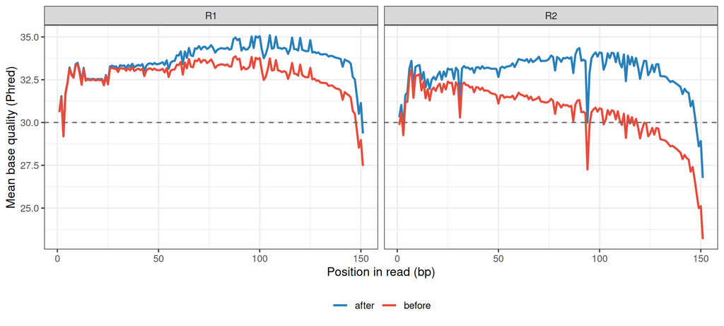

# Part 3 — Alignment with BWA-MEM

Alignment finds, for every read, the position in the reference genome it most likely came from. **BWA-MEM** is the standard aligner for short DNA reads. It first needs an **index** of the reference (built once per reference genome):

```bash
cp data/germline/reference_chr11p15.fa work/reference.fa
bwa index work/reference.fa 2> work/bwa_index.log
samtools faidx work/reference.fa
ls work/reference.fa*
```

```
## work/reference.fa
## work/reference.fa.amb
## work/reference.fa.ann
## work/reference.fa.bwt
## work/reference.fa.fai
## work/reference.fa.pac
## work/reference.fa.sa
```

Then we align, adding a **read group** (`-R`): a tag saying which sample and sequencing run every read belongs to, required by most downstream tools. The output (SAM) is piped directly into `samtools`, which sorts the alignments by position and writes the compressed **BAM** format.

```bash
bwa mem -t 2 \
  -R '@RG\tID:NA12878_run1\tSM:NA12878\tPL:ILLUMINA\tLB:TruSeq_exome' \
  work/reference.fa work/trimmed_R1.fastq.gz work/trimmed_R2.fastq.gz 2> work/bwa_mem.log |
  samtools fixmate -m - - |
  samtools sort -o work/aligned.bam -
samtools index work/aligned.bam
ls -lh work/aligned.bam
```

```
## -rw-rw-r-- 1 ciccio ciccio 13M nov  5 12:36 work/aligned.bam
```

**What `fixmate -m` does.** It adds to every read information about its mate (position, score). The duplicate-marking step below needs it to recognize pairs.

## Reading a SAM Record

```bash
samtools view work/aligned.bam | head -3 | cut -f 1-9
```

```
## HWI-ST1023:220:H84P1ADXX:1:2104:12417:19705  99  11  60736   60  151M    =   60766   181
## HWI-ST1023:220:H84P1ADXX:1:2104:12417:19705  147 11  60766   60  151M    =   60736   -181
## HWI-ST1023:220:H84P1ADXX:1:1204:19555:23802  163 11  60863   60  151M    =   60874   162
```

The first 9 columns of every alignment:

| # | field | meaning |
| --- | --- | --- |
| 1 | QNAME | read name |
| 2 | FLAG | bitwise flags: paired, mapped, reverse strand, first/second in pair… ([decode any value](https://broadinstitute.github.io/picard/explain-flags.html)) |
| 3–4 | RNAME, POS | chromosome and leftmost position (1-based) |
| 5 | MAPQ | mapping quality: confidence that the position is right. 60 = unique; 0 = the read fits equally well elsewhere |
| 6 | CIGAR | how the read aligns: `151M` = 151 aligned bases; `I`/`D` = insertion/deletion; `S` = soft-clipped |
| 7–9 | RNEXT, PNEXT, TLEN | mate’s chromosome (`=` same), mate’s position, fragment length |

## Marking PCR Duplicates

Library preparation amplifies DNA fragments by PCR, so the same original molecule can be sequenced several times. These copies are **not independent evidence**: a PCR error in one copy would look like a variant supported by many reads. `samtools markdup` flags read pairs that start and end at exactly the same positions; variant callers then ignore them.

```bash
samtools markdup -s work/aligned.bam work/aligned.markdup.bam 2> work/markdup.log
samtools index work/aligned.markdup.bam
grep -E "READ:|DUPLICATE TOTAL" work/markdup.log
```

```
## READ: 110413
## DUPLICATE TOTAL: 6903
```

# Part 4 — Alignment QC

```bash
samtools flagstat work/aligned.markdup.bam > work/flagstat.txt
head -n 8 work/flagstat.txt
```

```
## 110413 + 0 in total (QC-passed reads + QC-failed reads)
## 110058 + 0 primary
## 0 + 0 secondary
## 355 + 0 supplementary
## 6903 + 0 duplicates
## 6903 + 0 primary duplicates
## 110392 + 0 mapped (99.98% : N/A)
## 110037 + 0 primary mapped (99.98% : N/A)
```

```bash
total=$(samtools view -c -F 0x904 work/aligned.markdup.bam)
on_target=$(samtools view -c -F 0x904 -L data/germline/exome_targets.bed work/aligned.markdup.bam)
echo -e "mapped_reads\t$total\non_target_reads\t$on_target" | tee work/on_target.tsv
```

```
## mapped_reads 110037
## on_target_reads  75108
```

**68.3%** of the mapped reads overlap a target. This **on-target rate** measures how well the capture worked: typical exomes reach 60–80%. The rest are “off-target” reads, mostly from DNA flanking the targets.

## Coverage

**Coverage** (or depth) at a position is the number of reads covering it. It is the single most important number for variant calling: a heterozygous variant is seen in about half the reads, so with 4 reads it can easily be missed by chance.

```bash
# -a: report every targeted position, also those with zero reads.
samtools depth -a -b data/germline/exome_targets.bed work/aligned.markdup.bam > work/target_depth.tsv
head -3 work/target_depth.tsv
```

```
## 11   126988  1
## 11   126989  1
## 11   126990  1
```

Coverage over the exome targets (duplicates excluded).

| metric | value |
| --- | --- |
| Targeted bases | 257389.0 |
| Mean depth | 28.3 |
| Median depth | 5.0 |
| Bases at >= 1x (%) | 71.5 |
| Bases at >= 10x (%) | 44.9 |
| Bases at >= 20x (%) | 35.4 |

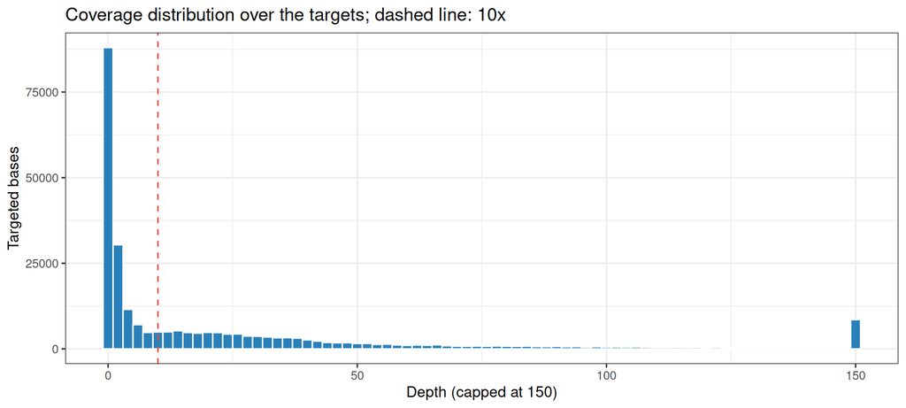

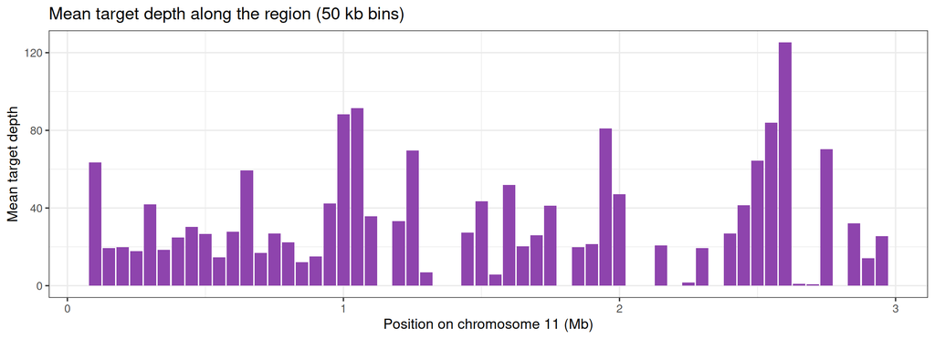

**Coverage is very uneven, and that matters.** Large parts of the targets have few or no reads. 11p15.5 is one of the most **GC-rich** regions of the genome, and GC-rich DNA is captured and amplified poorly. This is a real, well-known limitation of exome sequencing: **a variant in a region with no reads cannot be called, by any software.** We will see its direct consequence in Part 7.

# Part 5 — Variant Calling with bcftools

At every targeted position, `bcftools mpileup` collects the bases of all reads (the “pileup”) and computes **genotype likelihoods**: how probable the observed bases are if the sample is homozygous reference (0/0), heterozygous (0/1), or homozygous alternative (1/1). `bcftools call` then picks the most likely genotype and reports the positions that differ from the reference.

```bash
bcftools mpileup -f work/reference.fa -T data/germline/exome_targets.bed \
    -a FORMAT/AD,FORMAT/DP -q 20 -Q 20 work/aligned.markdup.bam 2> /dev/null |
  bcftools call -m -v -Oz -o work/calls.raw.vcf.gz 2> /dev/null
bcftools index -t work/calls.raw.vcf.gz
echo "Raw variant calls: $(bcftools view -H work/calls.raw.vcf.gz | wc -l)"
```

```
## Raw variant calls: 503
```

| option | meaning |
| --- | --- |
| `-T targets.bed` | look only at targeted positions |
| `-q 20`, `-Q 20` | ignore reads with mapping quality < 20 and bases with quality < 20 |
| `-a FORMAT/AD,FORMAT/DP` | report allele depths and total depth per sample |
| `call -m` | the multiallelic caller (current default model) |
| `call -v` | output variant sites only |

## Reading a VCF

A **VCF** (Variant Call Format) file has a header (lines starting with `#`) describing every field, then one line per variant.

```bash
bcftools view -H work/calls.raw.vcf.gz | head -3 | cut -f 1-8 | cut -c 1-150
```

```
## 11   127091  .   G   A   21.4353 .   DP=4;SGB=-0.379885;RPBZ=-1;FS=0;MQ0F=0;AC=1;AN=2;DP4=1,0,0,1;MQ=60
## 11   127447  .   G   A   113.466 .   DP=28;VDB=0.0833169;SGB=-0.590765;RPBZ=0.0413803;BQBZ=1.71619;SCBZ=-0.559017;FS=0;MQ0F=0;AC=1;AN=2;DP4=10,6,4,1;MQ=60
## 11   127467  .   G   A   195.406 .   DP=24;VDB=0.0348254;SGB=-0.662043;RPBZ=1.01916;BQBZ=-0.0905248;FS=0;MQ0F=0;AC=1;AN=2;DP4=4,5,7,2;MQ=60
```

```bash
bcftools query -f '%CHROM\t%POS\t%REF\t%ALT\t%QUAL\t[%GT\t%DP\t%AD]\n' work/calls.raw.vcf.gz | head -5
```

```
## 11   127091  G   A   21.4353 0/1 2   1,1
## 11   127447  G   A   113.466 0/1 21  16,5
## 11   127467  G   A   195.406 0/1 18  9,9
## 11   127487  C   G   225.417 1/1 19  0,19
## 11   127626  G   A   7.36271 0/1 71  64,7
```

The essential columns: `POS` (1-based position), `REF` and `ALT` alleles, `QUAL` (Phred-scaled confidence that the site is variant), and per sample `GT` (genotype: `0/1` heterozygous, `1/1` homozygous alternative), `DP` (depth) and `AD` (reads supporting REF, ALT).

# Part 6 — Filtering, Normalizing and Annotating

## Hard Filters

Raw calls include low-confidence ones. A simple, widely used strategy is to **flag** (not delete) calls with low quality or low depth. They stay in the file with `FILTER = LowQual`, so the decision is documented and reversible.

```bash
bcftools filter -s LowQual -e 'QUAL < 20 || INFO/DP < 10' work/calls.raw.vcf.gz -Oz -o work/calls.filtered.vcf.gz
bcftools index -t work/calls.filtered.vcf.gz
bcftools query -f '%FILTER\n' work/calls.filtered.vcf.gz | sort | uniq -c
```

```
##     180 LowQual
##     323 PASS
```

## Normalizing

The same indel can be written in several ways (e.g. a deletion inside a repeat can be placed at any copy of the repeat). `bcftools norm` puts every variant in a **canonical** form (left-aligned, minimal alleles) and splits multi-allelic sites into one line per allele. Without this, comparing two VCFs (as we do in Part 7) misses identical variants written differently.

```bash
bcftools norm -f work/reference.fa -m -any work/calls.filtered.vcf.gz -Oz -o work/calls.norm.vcf.gz 2> /dev/null
bcftools index -t work/calls.norm.vcf.gz
```

## Variant Statistics

```bash
bcftools stats -f PASS work/calls.norm.vcf.gz > work/calls.stats.txt
grep -E "^SN" work/calls.stats.txt | cut -f 3-
grep -E "^TSTV" work/calls.stats.txt | cut -f 3-5
```

```
## number of samples:   1
## number of records:   323
## number of no-ALTs:   0
## number of SNPs:  318
## number of MNPs:  0
## number of indels:    5
## number of others:    0
## number of multiallelic sites:    0
## number of multiallelic SNP sites:    0
## 193  125 1.54
```

**The Ts/Tv ratio, a free quality check.** Transitions (A↔︎G, C↔︎T) are chemically much more frequent than transversions. In **coding** regions the true ratio is about **2.8–3.3** (genome-wide ~2.0–2.1). A value close to 0.5, what random errors would give, signals many false positives.

Here the ratio is **1.54**: between the two. Part of the reason is that the targets also contain UTRs and intronic flanks, where the ratio is lower than in coding exons; part is a cluster of false positives that Part 7 will reveal. With a few hundred variants the ratio is also statistically noisy: it is most useful on a full exome, with tens of thousands.

## Functional Annotation

Which variants change a protein? `bcftools csq` compares each variant with the gene annotation and predicts its **consequence** on every transcript: synonymous, missense, stop gained, frameshift, splice site, UTR…

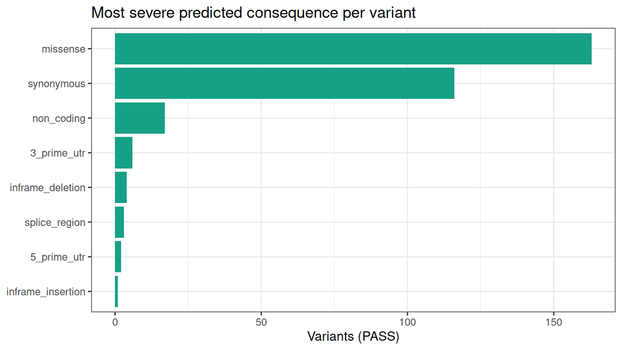

| position | ref | alt | genotype | depth | gene | consequence | aa_change | transcript |
| --- | --- | --- | --- | --- | --- | --- | --- | --- |
| 214421 | G | C | 0/1 | 34 | RIC8A | missense | 122G&gt;122R | ENST00000529275 |
| 233067 | C | T | 0/1 | 58 | SIRT3 | missense | 208V&gt;208I | ENST00000532956 |
| 237087 | A | G | 1/1 | 21 | PSMD13 | missense | 13N&gt;13S | ENST00000529372 |
| 244167 | C | T | 1/1 | 77 | PSMD13 | missense | 61P&gt;61S | ENST00000382671 |
| 244171 | T | C | 1/1 | 78 | PSMD13 | missense | 62F&gt;62S | ENST00000382671 |
| 244197 | T | C | 1/1 | 63 | PSMD13 | missense | 71C&gt;71R | ENST00000382671 |
| 280816 | A | T | 1/1 | 13 | NLRP6 | missense | 361Y&gt;361F | ENST00000312165 |
| 308290 | T | C | 0/1 | 54 | IFITM2 | missense | 13V&gt;13A | ENST00000533141 |
| 314207 | C | G | 1/1 | 33 | IFITM1 | missense | 13P&gt;13A | ENST00000328221 |
| 406043 | G | A | 1/1 | 15 | SIGIRR | missense | 459L&gt;459F | ENST00000531205 |

[output cut: 158 more lines]

```bash
bcftools csq -f work/reference.fa -g data/germline/genes_Ensembl87.gff3 -p a \
  work/calls.norm.vcf.gz -Oz -o work/calls.annotated.vcf.gz 2> /dev/null
bcftools index -t work/calls.annotated.vcf.gz

# One row per variant: position, alleles, genotype, and the consequence on each transcript.
bcftools query -i 'FILTER="PASS"' -f '%POS\t%REF\t%ALT\t%QUAL\t[%GT\t%DP]\t%BCSQ\n' \
  work/calls.annotated.vcf.gz > work/annotated_variants.tsv
```

**A healthy genome is full of missense variants.** NA12878 is a healthy individual, yet this one genome carries dozens of protein-changing variants in this small region alone: every person carries thousands across the exome. Most are common, harmless polymorphisms. In a real diagnostic analysis, the next step is to filter by **population frequency** (e.g. gnomAD: a variant carried by 20% of healthy people is not the cause of a rare disease) and by predicted pathogenicity, which requires databases far larger than this tutorial.

# Part 7 — How Good Are Our Calls? Benchmarking Against GIAB

We now compare our PASS calls with the GIAB truth, restricted to the positions where the comparison is fair: **targeted** by the exome kit **and** inside GIAB’s **high-confidence** regions.

```bash
bedtools intersect -a data/germline/exome_targets.bed -b data/germline/giab_confident.bed |
  bedtools sort | bedtools merge > work/eval_regions.bed

# Truth and calls in the evaluation regions, normalized the same way.
bcftools view -T work/eval_regions.bed data/germline/giab_truth.vcf.gz |
  bcftools norm -f work/reference.fa -m -any -Oz -o work/truth.eval.vcf.gz 2> /dev/null
bcftools view -f PASS -T work/eval_regions.bed work/calls.norm.vcf.gz -Oz -o work/calls.eval.vcf.gz
bcftools index -t work/truth.eval.vcf.gz
bcftools index -t work/calls.eval.vcf.gz

awk '{bp += $3 - $2} END {print "Evaluated bases: " bp}' work/eval_regions.bed
```

```
## Evaluated bases: 210117
```

`bcftools isec` splits the two files into three groups: variants **only in the truth** (false negatives, FN: real variants we missed), **only in our calls** (false positives, FP: calls that are not real), and **in both** (true positives, TP). `-c none` requires position, REF and ALT to match exactly.

```bash
rm -rf work/isec_all
bcftools isec -c none -p work/isec_all work/truth.eval.vcf.gz work/calls.eval.vcf.gz
for f in 0000 0001 0002; do echo "$f: $(grep -vc '^#' work/isec_all/$f.vcf)"; done
```

```
## 0000: 154
## 0001: 20
## 0002: 79
```

All evaluation regions. Recall = TP / (TP + FN): the fraction of real variants found. Precision = TP / (TP + FP): the fraction of our calls that are real.

| TP | FN | FP | recall | precision | F1 |
| --- | --- | --- | --- | --- | --- |
| 79 | 154 | 20 | 0.339 | 0.798 | 0.476 |

Recall is low. Why did we miss so many real variants? Look at the depth of our alignment at the missed positions:

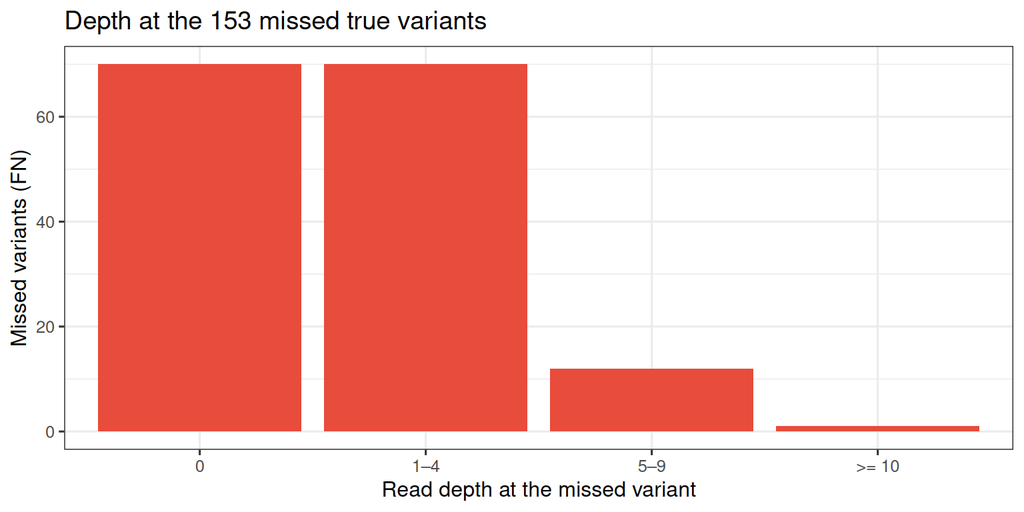

```bash
grep -v '^#' work/isec_all/0000.vcf | awk 'BEGIN{OFS="\t"} {print $1, $2 - 1, $2}' > work/missed.bed
samtools depth -a -b work/missed.bed work/aligned.markdup.bam > work/missed_depth.tsv
```

Repeating the benchmark only where we had **at least 10 reads** measures the pipeline itself:

```bash
samtools depth -a -b work/eval_regions.bed work/aligned.markdup.bam |
  awk 'BEGIN{OFS="\t"} $3 >= 10 {print $1, $2 - 1, $2}' |
  bedtools merge > work/callable.bed
awk '{bp += $3 - $2} END {print "Callable bases (>= 10x): " bp}' work/callable.bed

bcftools view -T work/callable.bed work/truth.eval.vcf.gz -Oz -o work/truth.callable.vcf.gz
bcftools view -T work/callable.bed work/calls.eval.vcf.gz -Oz -o work/calls.callable.vcf.gz
bcftools index -t work/truth.callable.vcf.gz
bcftools index -t work/calls.callable.vcf.gz
rm -rf work/isec_callable
bcftools isec -c none -p work/isec_callable work/truth.callable.vcf.gz work/calls.callable.vcf.gz
```

```
## Callable bases (>= 10x): 81908
```

Benchmark against the GIAB truth set.

| regions | TP | FN | FP | recall | precision | F1 |
| --- | --- | --- | --- | --- | --- | --- |
| All evaluation regions | 79 | 154 | 20 | 0.339 | 0.798 | 0.476 |
| Callable (>= 10x) | 79 | 1 | 20 | 0.988 | 0.798 | 0.883 |

Where the data are adequate, the pipeline finds nearly every real variant. What about the false positives?

```bash
bcftools query -f '%POS\t%REF\t%ALT\t%QUAL\t[%DP]\n' work/isec_callable/0001.vcf > work/false_positives.tsv
```

Genes containing the false-positive calls (callable regions).

| gene | false_positives |
| --- | --- |
| MUC5B | 15 |
| (outside annotated genes) | 4 |
| PTDSS2 | 1 |

# Summary

| step | tool | output |
| --- | --- | --- |
| Read QC and trimming | `fastp` | trimmed FASTQ + QC report |
| Alignment | `bwa mem` | BAM |
| Duplicate marking | `samtools fixmate` / `markdup` | BAM with duplicates flagged |
| Alignment QC | `samtools flagstat` / `depth` | on-target rate, coverage |
| Variant calling | `bcftools mpileup` / `call` | raw VCF |
| Filtering and normalization | `bcftools filter` / `norm` | clean VCF |
| Annotation | `bcftools csq` | consequences on genes |
| Benchmarking | `bedtools`, `bcftools isec` | recall, precision |

The main lessons: **coverage limits recall** far more than the caller does, and **false positives concentrate in repetitive genes**. Module 2 moves from one germline genome to a cohort of tumors.

Generated on 05 novembre 2026 · Francesco Cecere (Senior Bioinformatic Researcher) · AORN Santobono-Pausilipon IRCCS